# House prices prediction

## House prices prediction- Kaggle Project 1

### Danxuan Han

**This is a Kaggle project, to dig into the problem, I studied some notes from kaggle's kernel, inspired by their methods, and generated my own research report.**

**References:**  
1.[Comprehensive data exploration with Python](https://www.kaggle.com/pmarcelino/comprehensive-data-exploration-with-python)-- especially how to visualize data  
2.[A study on Regression applied to the Ames dataset](https://www.kaggle.com/juliencs/a-study-on-regression-applied-to-the-ames-dataset)-- espeicially how to deal with missing data

```python
import pandas as pd
import matplotlib.pyplot as plt
import seaborn as sns
import numpy as np
from scipy.stats import norm
from sklearn.preprocessing import StandardScaler
from scipy import stats
import warnings
warnings.filterwarnings('ignore')
%matplotlib inline
```

```python
df_train = pd.read_csv('train.csv')
```

```python
df_train.head()
```

|  | Id | MSSubClass | MSZoning | LotFrontage | LotArea | Street | Alley | LotShape | LandContour | Utilities | ... | PoolArea | PoolQC | Fence | MiscFeature | MiscVal | MoSold | YrSold | SaleType | SaleCondition | SalePrice |
| --- | --- | --- | --- | --- | --- | --- | --- | --- | --- | --- | --- | --- | --- | --- | --- | --- | --- | --- | --- | --- | --- |
| 0 | 1 | 60 | RL | 65.0 | 8450 | Pave | NaN | Reg | Lvl | AllPub | ... | 0 | NaN | NaN | NaN | 0 | 2 | 2008 | WD | Normal | 208500 |
| 1 | 2 | 20 | RL | 80.0 | 9600 | Pave | NaN | Reg | Lvl | AllPub | ... | 0 | NaN | NaN | NaN | 0 | 5 | 2007 | WD | Normal | 181500 |
| 2 | 3 | 60 | RL | 68.0 | 11250 | Pave | NaN | IR1 | Lvl | AllPub | ... | 0 | NaN | NaN | NaN | 0 | 9 | 2008 | WD | Normal | 223500 |
| 3 | 4 | 70 | RL | 60.0 | 9550 | Pave | NaN | IR1 | Lvl | AllPub | ... | 0 | NaN | NaN | NaN | 0 | 2 | 2006 | WD | Abnorml | 140000 |
| 4 | 5 | 60 | RL | 84.0 | 14260 | Pave | NaN | IR1 | Lvl | AllPub | ... | 0 | NaN | NaN | NaN | 0 | 12 | 2008 | WD | Normal | 250000 |

5 rows × 81 columns

```python
df_train.columns
```

```
Index(['Id', 'MSSubClass', 'MSZoning', 'LotFrontage', 'LotArea', 'Street',
       'Alley', 'LotShape', 'LandContour', 'Utilities', 'LotConfig',
       'LandSlope', 'Neighborhood', 'Condition1', 'Condition2', 'BldgType',
       'HouseStyle', 'OverallQual', 'OverallCond', 'YearBuilt', 'YearRemodAdd',
       'RoofStyle', 'RoofMatl', 'Exterior1st', 'Exterior2nd', 'MasVnrType',
       'MasVnrArea', 'ExterQual', 'ExterCond', 'Foundation', 'BsmtQual',
       'BsmtCond', 'BsmtExposure', 'BsmtFinType1', 'BsmtFinSF1',
       'BsmtFinType2', 'BsmtFinSF2', 'BsmtUnfSF', 'TotalBsmtSF', 'Heating',
       'HeatingQC', 'CentralAir', 'Electrical', '1stFlrSF', '2ndFlrSF',
       'LowQualFinSF', 'GrLivArea', 'BsmtFullBath', 'BsmtHalfBath', 'FullBath',
       'HalfBath', 'BedroomAbvGr', 'KitchenAbvGr', 'KitchenQual',
       'TotRmsAbvGrd', 'Functional', 'Fireplaces', 'FireplaceQu', 'GarageType',
       'GarageYrBlt', 'GarageFinish', 'GarageCars', 'GarageArea', 'GarageQual',
       'GarageCond', 'PavedDrive', 'WoodDeckSF', 'OpenPorchSF',
       'EnclosedPorch', '3SsnPorch', 'ScreenPorch', 'PoolArea', 'PoolQC',
       'Fence', 'MiscFeature', 'MiscVal', 'MoSold', 'YrSold', 'SaleType',
       'SaleCondition', 'SalePrice'],
      dtype='object')
```

```python
df_train['SalePrice'].describe()
```

```
count      1460.000000
mean     180921.195890
std       79442.502883
min       34900.000000
25%      129975.000000
50%      163000.000000
75%      214000.000000
max      755000.000000
Name: SalePrice, dtype: float64
```

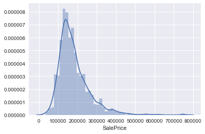

```python
sns.distplot(df_train['SalePrice'])
```

```python
print("Skewness: %f" % df_train['SalePrice'].skew())
print("Kurtosis: %f" % df_train['SalePrice'].kurt())
```

```
Skewness: 1.882876
Kurtosis: 6.536282
```

**1. Get a general idea of relationship of some variables pairs.**  
1.grlivarea/saleprice

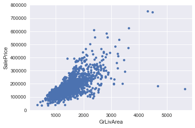

```python
var = 'GrLivArea'
data = pd.concat([df_train['SalePrice'], df_train[var]], axis=1)
data.plot.scatter(x=var, y='SalePrice', ylim=(0,800000))
```

Analysis: The shape seems to be a cone, which means, as the x variable increases, the variance of observation increases-Heteroscedasticity.

2.totalbsmtsf/saleprice

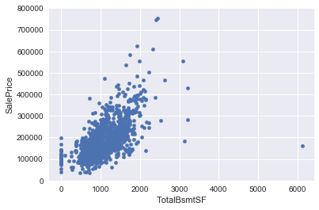

```python
var = 'TotalBsmtSF'
data = pd.concat([df_train['SalePrice'], df_train[var]], axis=1)
data.plot.scatter(x=var, y='SalePrice', ylim=(0,800000))
```

It's clear that sometimes 'TotalBsmtSF' closes in itself and gives zero credit to 'SalePrice'.

Next, relationship with categorical features.

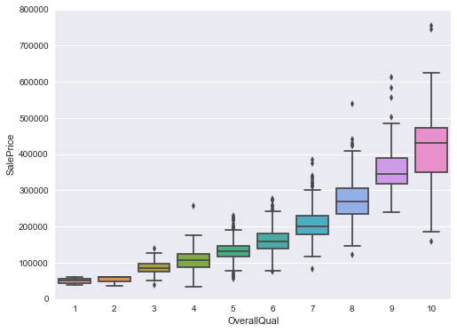

```python
#box plot overallqual/saleprice
var = 'OverallQual'
data = pd.concat([df_train['SalePrice'], df_train[var]], axis=1)
f, ax = plt.subplots(figsize=(8, 6))
fig = sns.boxplot(x=var, y="SalePrice", data=data)
fig.axis(ymin=0, ymax=800000);
```

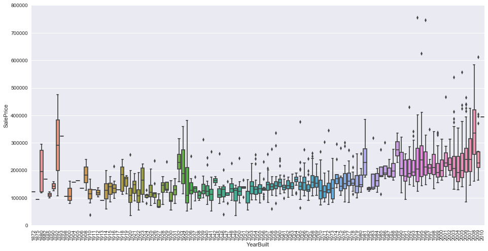

```python
var = 'YearBuilt'
data = pd.concat([df_train['SalePrice'], df_train[var]], axis=1)
f, ax = plt.subplots(figsize=(16, 8))
fig = sns.boxplot(x=var, y="SalePrice", data=data)
fig.axis(ymin=0, ymax=800000);
plt.xticks(rotation=90);
```

Note: should consider the effect of inflation

**2. Feature Selection**

1. Method: correlation matrix, SalePrice correlation matrix, scatter plots between the most correlated variables
2. Detect multicollinearity through heatmap of correlation.

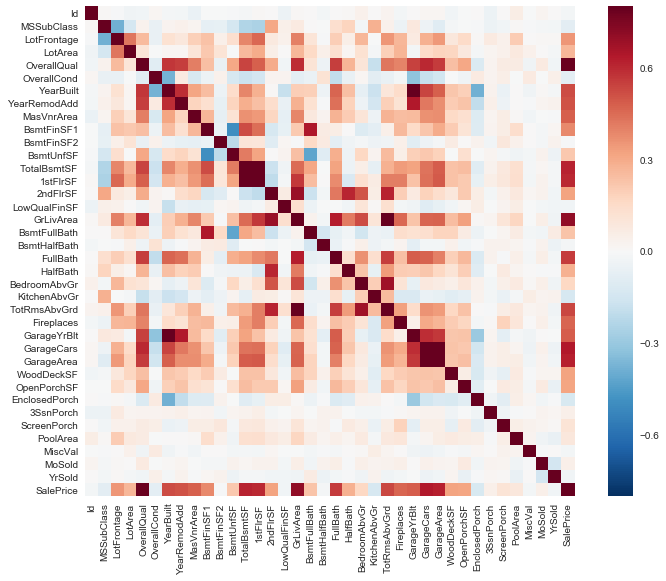

```python
#correlation matrix
corrmat = df_train.corr()
f, ax = plt.subplots(figsize=(12, 9))
sns.heatmap(corrmat, vmax=.8, square=True);
```

From the highly correlated pairs, we could know that GarageCars, GarageArea, GarageYrBlt, these three variables are highly correlated, if we put all these three into our final regression model, it may cause multicollinearity. The same analysis for the pair of 1stFlrSF and TotalBsmtSF, since these variables may includes almost same information.

Since we aimed at predicting saleprice, we want to know the variables highly correlated to it.

**Saleprice correlation marix**

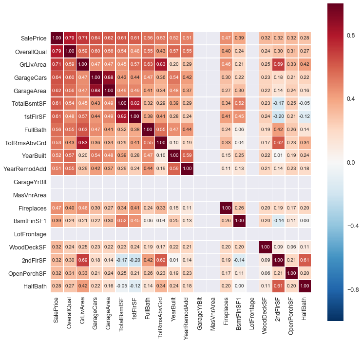

```python
k = 20 #number of variables for heatmap
cols = corrmat.nlargest(k, 'SalePrice')['SalePrice'].index
cm = np.corrcoef(df_train[cols].values.T)
sns.set(font_scale=1.25)
fig, ax = plt.subplots(figsize=(12,12))
hm = sns.heatmap(cm, cbar=True, annot=True, square=True, fmt='.2f', annot_kws={'size': 10}, \
                 yticklabels=cols.values, xticklabels=cols.values, linewidths=.5, ax=ax)
plt.show()
```

we do the feature selection one by one:  
(1) OverallQual, GrLivArea, checked  
(2) GarageCars, GarageArea, they contain same information, so we leave only one, GarageCars.  
(3) TotalBsmtSF and 1stFlrSF, they contain same information, so we leave only one, TotalBsmtSF.  
(4) TotalRmsAbvGrd, highly correlated to GrLivArea, delete.  
(5) We also include YearBuilt and YearRemodAdd

See what happens next and then add or delete other variables. (generally, feature selection could made through process of correlation matrix, dealing with missing data etc.)

**Scatter plot between SalePrice and those selected variables**

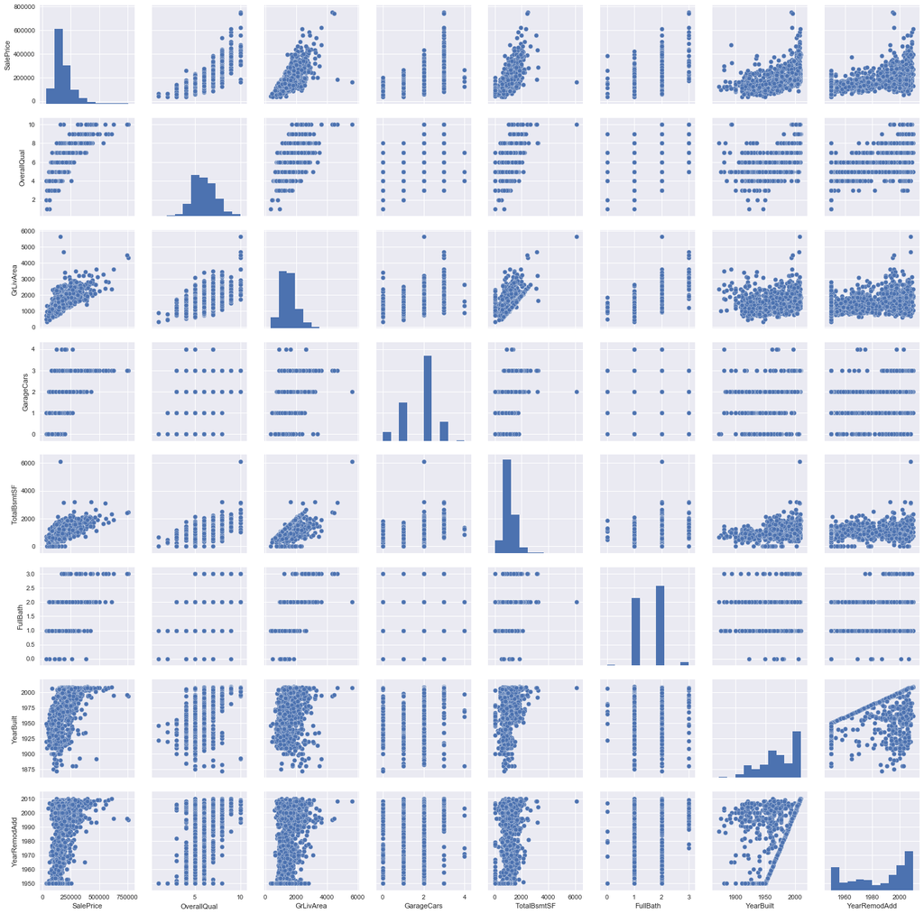

```python
#scatterplot
sns.set()
cols = ['SalePrice', 'OverallQual', 'GrLivArea', 'GarageCars', 'TotalBsmtSF', 'FullBath', \
        'YearBuilt','YearRemodAdd']
sns.pairplot(df_train[cols], size = 2.5)
plt.show()
```

**3. Missing data**  
This section answers two points  
(1) How to summarize missing data  
(2) How to takle with missing data-- when should delete the observations, when should delete the features

```python
total = df_train.isnull().sum().sort_values(ascending=False)
percent = (df_train.isnull().sum()/df_train.isnull().count()).sort_values(ascending=False)
missing_data = pd.concat([total, percent], axis=1, keys=['Total', 'Percent'])
missing_data.head(20)
```

|  | Total | Percent |
| --- | --- | --- |
| PoolQC | 1453 | 0.995205 |
| MiscFeature | 1406 | 0.963014 |
| Alley | 1369 | 0.937671 |
| Fence | 1179 | 0.807534 |
| FireplaceQu | 690 | 0.472603 |
| LotFrontage | 259 | 0.177397 |
| GarageCond | 81 | 0.055479 |
| GarageType | 81 | 0.055479 |
| GarageYrBlt | 81 | 0.055479 |
| GarageFinish | 81 | 0.055479 |
| GarageQual | 81 | 0.055479 |
| BsmtExposure | 38 | 0.026027 |
| BsmtFinType2 | 38 | 0.026027 |
| BsmtFinType1 | 37 | 0.025342 |
| BsmtCond | 37 | 0.025342 |
| BsmtQual | 37 | 0.025342 |
| MasVnrArea | 8 | 0.005479 |
| MasVnrType | 8 | 0.005479 |
| Electrical | 1 | 0.000685 |
| Utilities | 0 | 0.000000 |

Features selection rule:  
**(1)** if missing data's percent is higher than 0.15, then, delete the feature. But we would not delete them in this step, we should check those features with lots of missing values, why they are missing, what's the reason for missing and then decide whether delete them or not.  
**(2)** GarageX variables have same number of missing data, but we have already choose the variable of GarageCars to include GarageX's varables information.  
**(3)** From the 'data_description.txt' file, we decide to delete the variables of BsmtCond and BsmtQual, since we have already selected the feature of TotalBsmtSF to represent the information of basement.  
**(4)** for MasVnrType and MasVnrArea, the description says it means Masonry veneer type and Masonry veneer area in square feet, respectively. we could first take a look at the data of MasVnrArea and MasVnrType

```python
data = pd.concat([df_train['MasVnrArea'], df_train['MasVnrType']], axis=1)
data.head(20)
```

|  | MasVnrArea | MasVnrType |
| --- | --- | --- |
| 0 | 196.0 | BrkFace |
| 1 | 0.0 | None |
| 2 | 162.0 | BrkFace |
| 3 | 0.0 | None |
| 4 | 350.0 | BrkFace |
| 5 | 0.0 | None |
| 6 | 186.0 | Stone |
| 7 | 240.0 | Stone |
| 8 | 0.0 | None |
| 9 | 0.0 | None |
| 10 | 0.0 | None |
| 11 | 286.0 | Stone |
| 12 | 0.0 | None |
| 13 | 306.0 | Stone |
| 14 | 212.0 | BrkFace |
| 15 | 0.0 | None |
| 16 | 180.0 | BrkFace |
| 17 | 0.0 | None |
| 18 | 0.0 | None |
| 19 | 0.0 | None |

**(4)** Continue to the last point, we find that a lot of observations don't have Masonry veneer, so, maybe we could concate these two features and set a dummy variables of HaveMasonry, to represent if an observation has area convered by masonry or not.  
**(5)** Finally, we have one missing observation in 'Electrical'. Since it is just one observation, we'll delete this observation and keep the variable.

```python
#dealing with missing data
MasVnrType_isnull_series = df_train['MasVnrType'].isnull()

df_train['HaveMasonry'] = [0 if (MasVnrType_isnull_series.iloc[i] or df_train['MasVnrArea'].iloc[i]==0.0)
                           else 1 for i in range(len(df_train))]
df_train = df_train.drop(['MasVnrArea', 'MasVnrType'], axis=1)
```

```python
df_train = df_train.drop(['GarageCond','GarageType','GarageYrBlt','GarageFinish','GarageQual',\
                          'BsmtExposure','BsmtFinType2','BsmtFinType1','BsmtCond','BsmtQual'], axis=1)
```

**we leave this part for**  
**1. how to deal with other features with missing data but have not yet found other variables substitute them.**

**4. Outliers**  
**How to find outlier:**  
(1) standardize data-- converting data values to have mean of 0 and a standard deviation of 1

```python
saleprice_scaled = StandardScaler().fit_transform(df_train['SalePrice'][:,np.newaxis]);
low_range = saleprice_scaled[saleprice_scaled[:,0].argsort()][:10]
high_range= saleprice_scaled[saleprice_scaled[:,0].argsort()][-10:]
print('outer range (low) of the distribution:')
print(low_range)
print('\nouter range (high) of the distribution:')
print(high_range)
```

```
outer range (low) of the distribution:
[[-1.83870376]
 [-1.83352844]
 [-1.80092766]
 [-1.78329881]
 [-1.77448439]
 [-1.62337999]
 [-1.61708398]
 [-1.58560389]
 [-1.58560389]
 [-1.5731    ]]

outer range (high) of the distribution:
[[ 3.82897043]
 [ 4.04098249]
 [ 4.49634819]
 [ 4.71041276]
 [ 4.73032076]
 [ 5.06214602]
 [ 5.42383959]
 [ 5.59185509]
 [ 7.10289909]
 [ 7.22881942]]
```

We could pay attention to those 7.something values

(2) Another way is to do bivariate analysis and plot the data to see if there exists outliers.  
(3) qqplot also could help detect outliers, [see here](https://www.itl.nist.gov/div898/handbook/eda/section3/eda33o.htm)

**5. Normal probabilty plot--identify substantive departures from normality.**  
QQ plot  
1.[how to plot QQ-plot](https://www.youtube.com/watch?v=okjYjClSjOg)  
2.if skewness, transform to normal distribution -- log transformation,  
if there is a significant number of value zero, can't do log transformation-->how to deal?--create binary variable

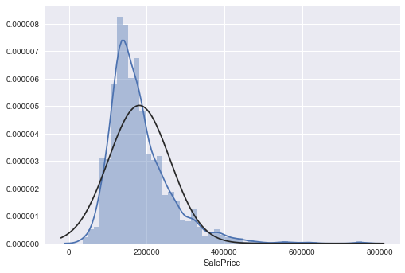

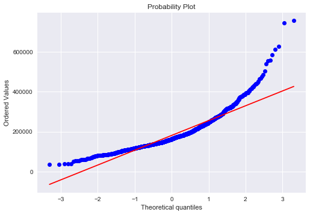

```python
#histogram and normal probability plot
sns.distplot(df_train['SalePrice'], fit=norm);
fig = plt.figure()
res = stats.probplot(df_train['SalePrice'], plot=plt)
```

We could tell that 'SalePrice' is not normal distributed, it has positive skewness, so we are going to do log-transformation.

```python
df_train['SalePrice'] = np.log(df_train['SalePrice'])
```

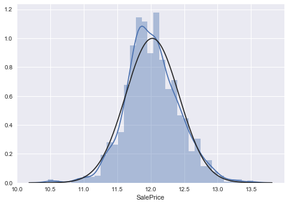

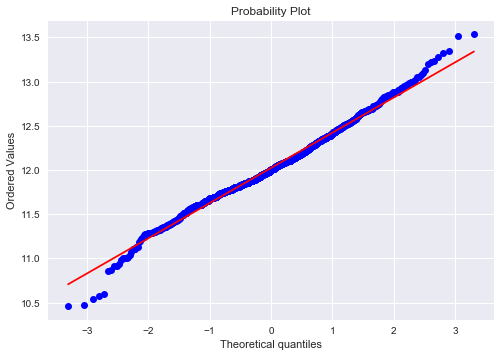

```python
#transformed histogram and normal probability plot
sns.distplot(df_train['SalePrice'], fit=norm);
fig = plt.figure()
res = stats.probplot(df_train['SalePrice'], plot=plt)
```

for the feature of 'GrLivArea'

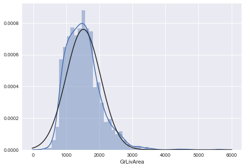

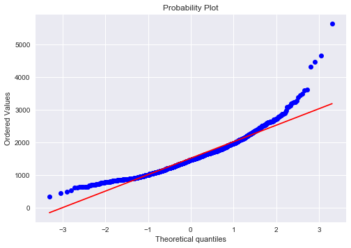

```python
sns.distplot(df_train['GrLivArea'], fit=norm);
fig = plt.figure()
res = stats.probplot(df_train['GrLivArea'], plot=plt)
```

```python
df_train['GrLivArea'] = np.log(df_train['GrLivArea'])
```

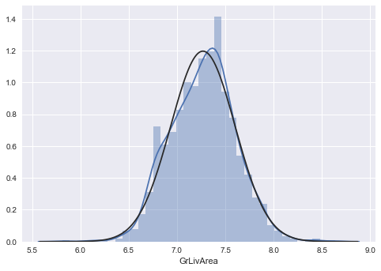

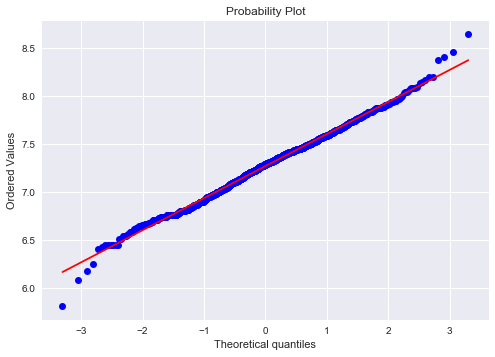

```python
sns.distplot(df_train['GrLivArea'], fit=norm);
fig = plt.figure()
res = stats.probplot(df_train['GrLivArea'], plot=plt)
```

For the feature of 'TotalBsmtSF' (total square feet basement area)

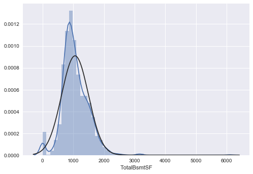

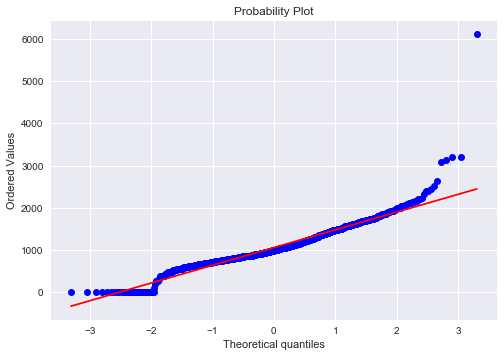

```python
sns.distplot(df_train['TotalBsmtSF'], fit=norm);
fig = plt.figure()
res = stats.probplot(df_train['TotalBsmtSF'], plot=plt)
```

Here we got the problem, since the distribution of 'TotalBsmtSF' is positive skewness, so we intend to do log-transformation, however, 'TotalBsmtSF' has a lot of zero values, which couldn't be transformed by log-transformation.

The author of one notes provided the solution: **to apply a log transformation here, we'll create a variable that can get the effect of having or not having basement (binary variable). Then, we'll do a log transformation to all the non-zero observations, ignoring those with value zero. This way we can transform data, without losing the effect of having or not basement.**

```python
df_train['HasBsmt'] = pd.Series(len(df_train['TotalBsmtSF']), index=df_train.index)
df_train['HasBsmt'] = 0
df_train.loc[df_train['TotalBsmtSF']>0,'HasBsmt'] = 1
```

```python
df_train.loc[df_train['HasBsmt']==1,'TotalBsmtSF'] = np.log(df_train['TotalBsmtSF'])
```

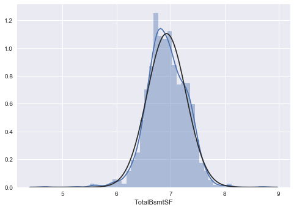

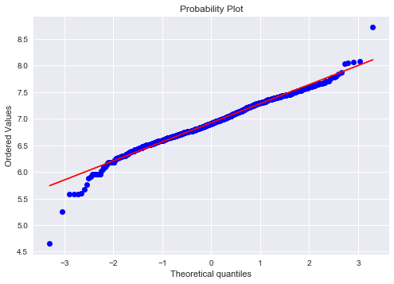

```python
sns.distplot(df_train[df_train['TotalBsmtSF']>0]['TotalBsmtSF'], fit=norm);
fig = plt.figure()
res = stats.probplot(df_train[df_train['TotalBsmtSF']>0]['TotalBsmtSF'], plot=plt)
```

**6.Suggestions**  
1.**From one of the comments:** inspect the residuals plots to detect any non-linear relationships-- it comes down to how well we can model this without increasing the variance of the estimate by too much. Except for small data sets, the best-performing predictive models will probably model this nonlinearity with things like regression splines. In practice, this problem can only be decided upon by trying different models (with, in particular, different degree of regularization) to see which model has the lowest mean squared error on withheld data.

use a more formal procedure for feature selection and be very hesitant to throw away any data. if the regression coefficients of the respective variables are unstable, I would see how much worse the model performs (again using withheld data) if I just use one. An even better solution would be to extract the principal components and use those as predictors instead.

I want to stress that multivariate normality of the data is NOT an assumption of regression analysis (which is probably the most natural approach for this problem) . Instead, it assumes that the error terms are normally distributed (i.e., y given X). Again, we need to inspect the residual plot to check this. Similarly, homoscedasticity refers to the conditional distribution of y given X, so again we need to look at the error terms if we want to plot this in two dimensions.

what I usually look for (in addition to whether the dependent variable is asymmetrically distributed) is unexpected patterns in the data – e.g., cutoff thresholds – that would be hard to detect otherwise, and maybe even indicate problems with the data.